### Data Scientist vs Statistician

A statistician takes data, typically from a designed experiment (often the statistician is involved in the design) and produces particular sorts of *answers*.

A data scientist takes “raw” data (which might be generated by some non- experimental process like an application that uses a database) and generates *questions.*

[figure not shown]

### Tasks data scientists do:

1. Visualization
2. Exploratory Data Analysis
3. ETL (Extract, Transform, Load)
4. Application Development
5. Operations (setting up pipelines between databases and models)
6. Orchestrating Data Collection Standards
7. Lots else.

### Scientific Research with Computers

This course will also be useful for anyone doing research with computers. If you are doing non-trivial statistical analysis or simulation, the methods we cover here will let you do so in an organized, portable, comprehensible way.

### Data Science Project Lifetime

Science is the orderly passage through this graph:

[figure not shown]

…

### Data Science Project Lifetime

Science is the dis-orderly passage through this graph:

[figure not shown]

### Good Data Science

[figure not shown]

### Elaboration

We want to convert an ad-hoc, disordered, process into one in which each phase is represented and each change is recorded along with meaningful context.

### Goofus

Goofus Presents Preliminary Results at BIOCON 2019 and publishes a paper in 2021. A colleague asks why a large p-value (reported in 2019) is much smaller in 2021.

Goofus just has a folder on his hard drive with a giant notebook in it. He has a backup from late 2019 but has no idea what of the many changes he has made since then changed the p-value. Also, he doesn't have previous data set - having replaced it with an updated one.

[figure not shown]

### Gallant

[figure not shown]

### Not Just Version Control

By far the most useful tool you'll learn here is Git.

But you will also need these tools to make your work *really reproducible*:

1. Unix Skills - tie everything together
2. Programming Skills - R and Python and Shell
3. Docker - reproducible development environments
4. Make - reproducible builds

### Non-Tools

Jupyter/RMarkdown

These are ok tools for exploratory work and quick write ups. I encourage you to use them if you'd like. These slides are RMarkdown.

But they are bad tools for reproducible data science.

1. They obscure dependencies
2. They maintain a lot of global state
3. They discourage “factoring”
4. They impose a modest technical lock in
5. They don't play well with git
6. They interleave *reporting* with *processing* and these are fundamentally disjoint tasks.

### Analysis

While I'm hardly a statistician and you all probably know more than I do, we will also cover:

1. Exploratory Data Analysis in R and Python
2. Processing, Joining and Cleaning Data
3. Visualization
4. Modeling (clustering, classification)

### Things To Do Before Next Class

Visit these sites:

https://www.kaggle.com/ https://github.com/awesomedata/awesome-public-datasets

https://duckduckgo.com/?q=open+data+sets&t=newext&atb=v234-1&ia=web

### Things to Try Before Next Class

1. Get a docker environment running. You should be able to do this in Windows or Linux or Mac. https://docs.docker.com/get-started/ On windows you can install Docker directly or install a Linux virtual Machine via Virtualbox. The latter is a bit more heavyweight a solution but will make your life easier in the long run.

### Course Material

Located here:

https://github.com/Vincent-Toups/datasci611

### Critical Things 1

Technical work is unfortunately very detail oriented. Get used to reading error and other messages very carefully. They have good information and usually tell you directly what the problem is or at least give you a good lead.

### Critical Things 2

There are a few really small things which screw up tons of people every year and I'm going to have to talk about them maybe hundreds of times.

1. Quotation marks. ASCII defines single (') and double (“) quotation marks. Note that these quotation marks are symmetric: we use them to open and close quoted parts of some text "like this.”

Unicode gives us an utter embarassment of quotation marks: ‘’“”‛‟❛❜❝❞

While these are all picturesque in almost all technical contexts you will need to use the ascii quotation marks.

### Critical Things 3

Pay attention to whitespace! There are tabs and spaces and newlines. These are all “invisible” “ ” but again often mean specific things in a technical context. It will be useful to have a text editor that shows and color codes whitespace.

### Chat GPT

Go nuts, but consider:

“Every extension of mankind, especially technological extensions, has the effect of amputating or modifying some other extension[…] The extension of a technology like the automobile ‘amputates’ the need for a highly developed walking culture, which in turn causes cities and countries to develop in different ways. The telephone extends the voice, but also amputates the art of penmanship gained through regular correspondence. These are a few examples, and almost everything we can think of is subject to similar observations…We have become people who regularly praise all extensions, and minimize all amputations.” –Marshall McLuhan Also consider: I find GPT3.5 to be almost uselessly dumb. Better to just learn to program. But I am not banning GPT because it can't really do high level data analysis, which is what this class is really about.

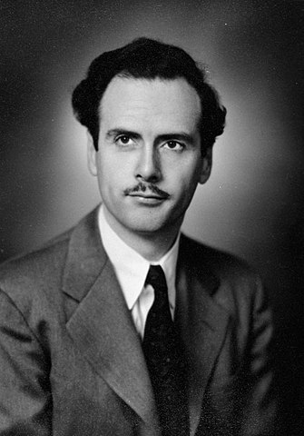

### Docker

The course is much more fun if you can install Docker on your personal computer or laptop. This may not be easy for all of you (especially if you have Apple Silicon). Everyone in the course can get a virtual machine for the semester which will have Docker pre-installed. If you have an Apple Silicon machine or just don't want to screw around with installing Docker on your laptop, email me and I will set one up for you.

### Projects

Don't sleep on your project. It is half your grade and also the best way to learn the material (by applying it to your own work). Don't worry if you don't find anything interesting. Reporting negative results is a very important skill and you can always pivot to a new data set in search of more interesting stuff. Your project doesn't need to consist of just one type of data.

### Homework

1. Pick a data set you might find interesting.
2. Write a pitch for your analysis (~500 words). What do you hope to learn by looking at it in detail?

Submit a document to Canvas with:

- a picture of your face
- a phonetic pronunciation of your preferred name and pronouns
- something interesting about you (or something boring)